# Calidad

Para llevar a cabo la gestión de la calidad, primero es importante comprender claramente qué es la calidad.

- Calidad requerida y elementos de calidad.
- Calidad prevista y calidad resultante.
- Características de la calidad y características sustitutas.
- Calidad esperada y calidad atractiva.
- Calidad del servicio y calidad del trabajo.
- Calidad social.
- Satisfacción del cliente (CS) y valor para el cliente.

[Audio_1](https://drive.google.com/file/d/1NlZIPQeLKY1LQP6s08TJhmbKaGcbFLSU/view?usp=drive_link)

```python
import os

try:
  os.chdir('../Python/QCKentei3')
except:
  pass

path = os.getcwd()
```

## 09-01 Concepto de calidad

品質の概念

### 1. Definición de calidad

品質の定義

**Quality**: 品質 Es el grado en que el conjunto de características inherentes de un objeto cumple con los requisitos.

Se puede decir que un producto de buena calidad es aquel que funciona como el cliente (usuario, persona de otra empresa, persona de otro departamento, etc.) espera, y que también es fiable porque tiene **poca variación**（ばらつきの少ない）.

### 2. Calidad requerida y elementos de calidad, Características de calidad y características de calidad y características sustituidas

要求品質と品質要素、品質特性と代用特性

Para discutir la calidad de un producto o servicio, es común desglosado en propiedades y características individuales que la componen. Esta técnica se conoce como **despliegue de la calidad**（品質展開）, y las propiedades y características individuales desglosadas se denomina **elementos de calidad**（品質要素）. Ejemplos concretos incluyen, la funcionalidad, el rendimiento, la usabilidad, la seguridad y la fiabilidad.

La **característica de calidad**（品質特性） es la medida que expresa más concretamente los elementos de calidad que componen un producto, es decir, el estándar que indica la diferencia en las propiedades de un producto o servicio.

El **requisito de calidad**（要求品質） se refiere a los requisitos relacionados con la calidad de un producto. También se utiliza para designar, de forma general, las cualidades tanto latentes como manifiestas que el mercado (los clientes) desea.

Además, una tabla de dos dimensiones, que despliega los requisitos de calidad y las características de calidad, se denomina **tabla de calidad**（品質表）.

La **calidad en uso**（使用品質） se refiere a lo bueno que es un producto cuando el comprador lo utiliza en situaciones reales.

**Característica de calidad sensorial**（官能品質） se refiere a aquellas características de calidad, como el color, el sabor, el olor o el tacto, que son juzgadas por los sentidos humanos.

La **características sustitutas**（代用特性） son otras características de calidad utilizadas como sustituto cuando es difícil medir directamente la característica de calidad requerida. Es decir, son el resultado de reemplazar una característica sensorial con una característica de calidad que puede ser implementada en la fábrica.

[Audio_2](https://drive.google.com/file/d/1K3tt7LqCGJ9YghPRJr97x0cvs5-rVNa_/view?usp=drive_link)

### 3. Calidad objetivo y calidad del resultado

狙いの品質と出来栄えの品質

**Calidad objetivo**: 狙いの品質 Se refiere a la calidad que se pretende alcanzar al comprender correctamente los requisitos del cliente (calidad requerida) y considerar suficientemente la capacidad para lograrlos. También se conoce como calidad de diseño.

**Calidad de ejecución**: 出来栄えの品質 Es la calidad relacionada con el grado de fidelidad con el que se ha logrado la calidad objetivo (calidad de diseño). También se conoce como calidad de fabricación, calidad de conformidad o calidad de ajuste.

**Objetivo de calidad** （品質目標） es el nivel técnico que se espera alcanzar para una fecha determinada, aunque se dude de que se pueda lograr con las capacidades (tecnología) actuales. Se establece principalmente para departamentos como investigación, diseño y tecnología. Generalmente, los objetivos de calidad se fijan para la calidad del diseño.

**Estándar de calidad**（品質標準） es el nivel técnico que actualmente se considera satisfactorio y que se puede lograr con las capacidades (tecnología) ya existentes. Se establece principalmente para el departamento de manufactura. Generalmente, los estándares de calidad se fija para la calidad de la producción.

### 4. Calidad esperada y calidad atractiva

当たり前品質と魅力的品質

**Calidad esperada**: 当たり前品質 Se refiere a los elementos de calidad que, cuando se cumplen, se consideran algo natural, pero cuando no se satisfacen, generan insatisfacción.

**Calidad atractiva**: 魅力的品質 Se refiere a los elementos de calidad que, cuando se cumplen, generan satisfacción, pero cuya ausencia es aceptada sin generar insatisfacción.

**Calidad unidimensional**: Se refiere a los elementos de calidad que, cuando se cumplen, generan satisfacción, pero cuya ausencia provoca insatisfacción.

Si bien la satisfacción física del diseñador con un producto (por ejemplo, la velocidad de procesamiento de una computadora, la resolución de una imagen) y la satisfacción del cliente no siempre son directamente proporcionales, se pueden considerar varios patrones de elementos de calidad si se observa la satisfacción física y la satisfacción del cliente en un espacio bidimensional, como se muestra en la Figura 9.1.

**El elemento de calidad indiferente**（無関心品質） es un elemento de calidad que no genera ni satisfacción ni insatisfacción, sin importar si está presente o ausente.

**El elemento de calidad inverso**（逆品質要素） es un elemento de calidad que causa insatisfacción cuando se cumple o genera satisfacción cuando es deficiente.

[Audio_3](https://drive.google.com/file/d/128Z0iTLjCOssWP55QSF1v-V51r0CbguK/view?usp=drive_link)

```
Figura 9.1: Gráfico bidimensional de la satisfacción físca y la satisfacción del cliente.
```

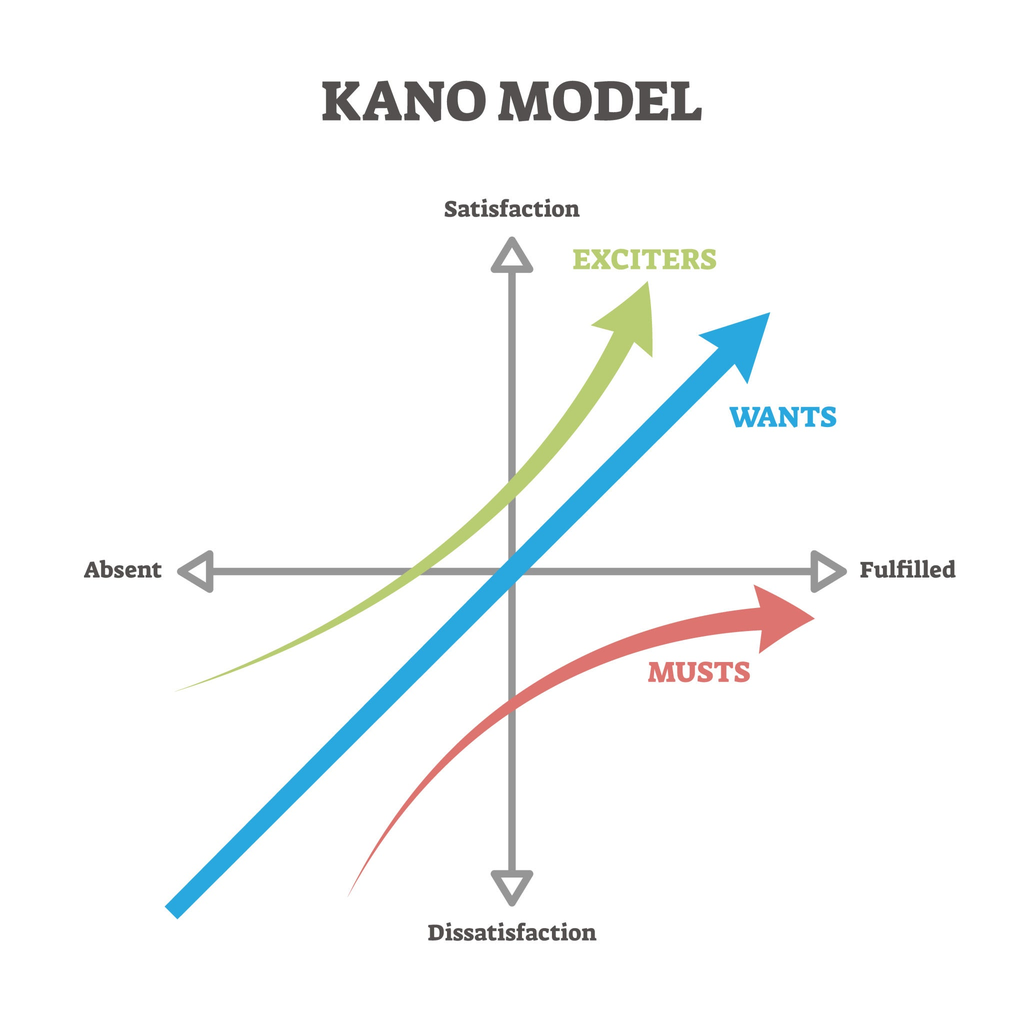

```python
from PIL import Image
print("Figura 9.1: Gráfico bidimensional de la satisfacción físca y la satisfacción del cliente.")

img = Image.open('./Graph3/licensed-image.jpeg')
display(img)
```

### 5. Calidad del servicio / Calidad del trabajo

サービスの品質、仕事の品質

En la gestión de calidad de los departamentos de administración y ventas, así como en las industrias de ocio, transporte, telecomunicaciones e información, suministro de energía y bienestar, **la calidad del servicio también se considera calidad**（サービスの質も品質）.

**La calidad del proceso de entrega del servicio**: Esto incluye aspectos como el trato y la respuesta de los empleados durante la prestación del servicio, así como la facilidad de uso de las instalaciones.

**La calidad del resultado del servicio**: Esto se refiere a si se produjeron cambios favorables como resultado del servicio.

La calidad en la industria manufacturera se crea a través de la colaboración en cada una de las actividades: desarrollo y diseño de productos, compras, producción, ventas y servicios postventa.

Esta calidad se compone de la **calidad del producto**（製品の質）, la **calidad del servicio**（サービスの質）, como base para ambas, la **calidad del trabajo**（仕事の質） de cada empleado. Lo que obtienes cuando estos tres elementos se unen es **la calidad**. Solo cuando se garantizan estos tres elementos, el producto se convierte en uno que responde a la confianza del cliente.

Para mejorar la **calidad del trabajo**, cada empleado en su respectiva área debe esforzarse por mejorar constantemente, manteniendo una alta conciencia de los problemas. Y al mismo tiempo, todos los departamentos deben colaborar estrechamente para poner en práctica la filosofía de **el cliente primero（お客様第一）, la calidad primero（品質第一）**.

### 6. Calidad social

社会的品質

**La calidad social** es un elemento de calidad que se refiere al grado en que un producto, servicio o su proceso de entrega satisface las necesidades de terceros.

### 7. Satisfacción del cliente (CS), Valor para el cliente

顧客満足（CS）、顧客価値

**Satisfacción del cliente**: se refiere al estado en el que el cliente que sus deseos o necesidades han sido satisfechos con el producto o servicio.

Para una empresa, la **Customer Satisfaction (CS)** no es solo una evaluación de si sus actividades de marketing coinciden con las necesidades del cliente. Es un concepto crucial para la **adquisición y retención de clientes**, ya que ayuda a asegurar que los clientes vuelvan a comprar productos o servicios, y evita que se cambien a la competencia.

**Valor para el cliente**（顧客価値） se refiere al valor que un cliente percibe a través de un producto o servicio.

[Audio_4](https://drive.google.com/file/d/1ViTgdJU9_dKt68axuUJUyNwyW2QT9IyA/view?usp=drive_link)

## Por favor, responda a las preguntas del examen de práctica a través del siguiente enlace.

[Simulacro de examen](https://forms.gle/w7kzb1TMv66VnnBZ7))

```python
from IPython.display import display
from PIL import Image
import gdown
import re

def get_file_id(url,out):
    # 正規表現でファイルIDを抽出
    match = re.search(r'/d/([a-zA-Z0-9_-]+)', url)

    if match:
        file_id = match.group(1)
        print("ファイルID:", file_id)
    else:
        print("ファイルIDが見つかりませんでした。")

    url = f"https://drive.google.com/uc?id={file_id}"

    output = out

    gdown.download(url, output, quiet=False)

    img = Image.open(out)
    display(img)
```

```python
url= 'https://drive.google.com/file/d/100Tu3Esj_T4HR29T95X2NrLKYl3UVLng/view?usp=drive_link'
out = './Graph3/licensed-image.jpeg'
#get_file_id(url,out)
```

```python
notebook_name = 'QCKentei3-9.ipynb'
notebook_name_html = notebook_name.replace(".ipynb",".html")

!jupyter nbconvert --to html {notebook_name}
```

```
[NbConvertApp] Converting notebook QCKentei3-9.ipynb to html
[NbConvertApp] Writing 2733692 bytes to QCKentei3-9.html
```